# Chapter 5: Dimensionality reduction

Again starting off by loading all the packages needed for this analysis:

```r
library(dplyr)
```

```r
library(ggplot2)
library(GGally)
library(stringr)
library(tidyr)
human <- read.csv("data/human.csv", row.names = 1, header=TRUE)
```

## Data

The dataset used in these analysis is a dataset that lists all countries of the world, their Human Development Index (HDI), as well as other related statistical indicators. As UNDP states, teh “The Human Development Index (HDI) is a summary measure of average achievement in key dimensions of human development: a long and healthy life, being knowledgeable and have a decent standard of living. The HDI is the geometric mean of normalized indices for each of the three dimensions.”

For the purposes of this analysis the data has been combined with information about Gender Inequality Index (GII). From the GII two ratios were calculated and stored as variables: the ratio of Female and Male populations with secondary education, and the ratio of labour force participation of females and males in each country. Finally, continent and world level summary datapoints were removed, as well as all observations with missing values (this is a prerequisite of the following analysis method).

All the original data is collected by the United Nations Development Programme ([more information here](http://hdr.undp.org/en/content/human-development-index-hdi)).

The modified dataset has 155 observations and 8 variables. See descriptions of variables in [table1] below.

| Variable | Description |
| --- | --- |
| GNI | Gross National Income per capita |
| Life_Exp | Life expectancy at birth |
| Edu_Exp | Expected years of education |
| MatMor | Maternal mortality ratio |
| Ado.Birth | Adolescent birth rate |
| Parlament_rep_F | Percetange of female representatives in parliament |
| FM_Ratio_Edu | Ratio of the proportion of females with at least secondary education |
| FM_Ratio_Lab | Ratio of the proportion of females in the labour force |

```r
# explore data dimension and structures
dim(human)
```

```
## [1] 155   8
```

```r
str(human)
```

```
## 'data.frame':    155 obs. of  8 variables:
##  $ FM_Ratio_Edu   : num  1.007 0.997 0.983 0.989 0.969 ...
##  $ FM_Ratio_Lab   : num  0.891 0.819 0.825 0.884 0.829 ...
##  $ Life_Exp       : num  81.6 82.4 83 80.2 81.6 80.9 80.9 79.1 82 81.8 ...
##  $ Edu_exp        : num  17.5 20.2 15.8 18.7 17.9 16.5 18.6 16.5 15.9 19.2 ...
##  $ GNI_Cap        : int  64992 42261 56431 44025 45435 43919 39568 52947 42155 32689 ...
##  $ MatMor         : int  4 6 6 5 6 7 9 28 11 8 ...
##  $ Ado.Birth      : num  7.8 12.1 1.9 5.1 6.2 3.8 8.2 31 14.5 25.3 ...
##  $ Parlament_rep_F: num  39.6 30.5 28.5 38 36.9 36.9 19.9 19.4 28.2 31.4 ...
```

Next, let’s use pairs to get a graphical overview of the data. Life expectancy and expected years of education are positively correlated. Maternal mortality rates and adolescent birth rate are are heavily correlated, as well as maternal mortality and life expectancy, which together indicate that giving more labours is a risk to the morther’s health. Similarly both life expectancy and expected years of education are negatively correlated with adolescent mortality and maternal mortality rates. Fnally, GNI seems to correlate positively with larger life expectancy and with expected years of education.

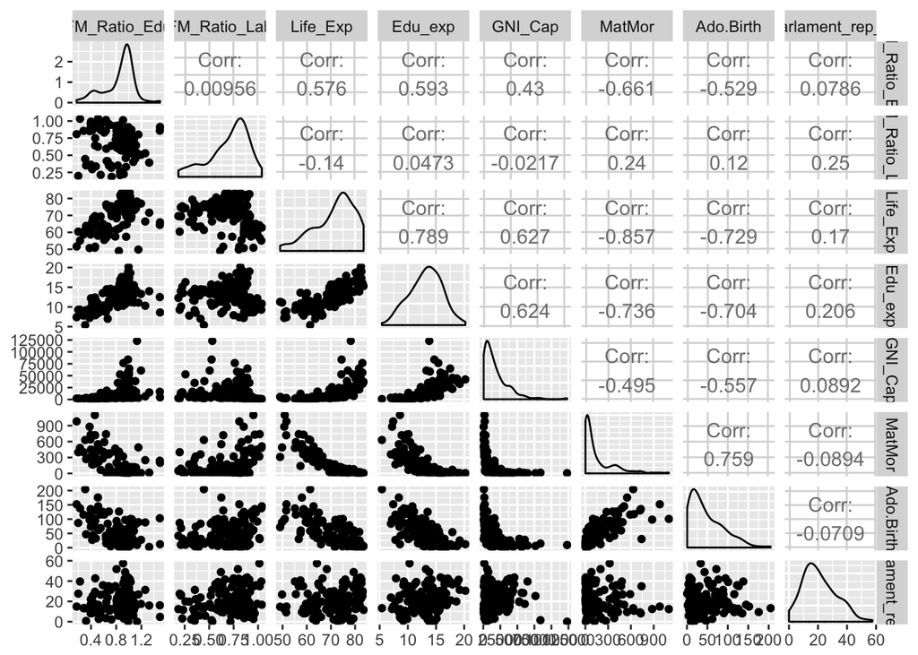

```r
ggpairs(human)
```

```r
summary(human)
```

```
##   FM_Ratio_Edu     FM_Ratio_Lab       Life_Exp        Edu_exp
##  Min.   :0.1717   Min.   :0.1857   Min.   :49.00   Min.   : 5.40
##  1st Qu.:0.7264   1st Qu.:0.5984   1st Qu.:66.30   1st Qu.:11.25
##  Median :0.9375   Median :0.7535   Median :74.20   Median :13.50
##  Mean   :0.8529   Mean   :0.7074   Mean   :71.65   Mean   :13.18
##  3rd Qu.:0.9968   3rd Qu.:0.8535   3rd Qu.:77.25   3rd Qu.:15.20
##  Max.   :1.4967   Max.   :1.0380   Max.   :83.50   Max.   :20.20
##     GNI_Cap           MatMor         Ado.Birth      Parlament_rep_F
##  Min.   :   581   Min.   :   1.0   Min.   :  0.60   Min.   : 0.00
##  1st Qu.:  4198   1st Qu.:  11.5   1st Qu.: 12.65   1st Qu.:12.40
##  Median : 12040   Median :  49.0   Median : 33.60   Median :19.30
##  Mean   : 17628   Mean   : 149.1   Mean   : 47.16   Mean   :20.91
##  3rd Qu.: 24512   3rd Qu.: 190.0   3rd Qu.: 71.95   3rd Qu.:27.95
##  Max.   :123124   Max.   :1100.0   Max.   :204.80   Max.   :57.50
```

```r
#library(corrplot)
#corrplot(human)
```

Next, let’s run Principal Component Analysis without scaling the data.

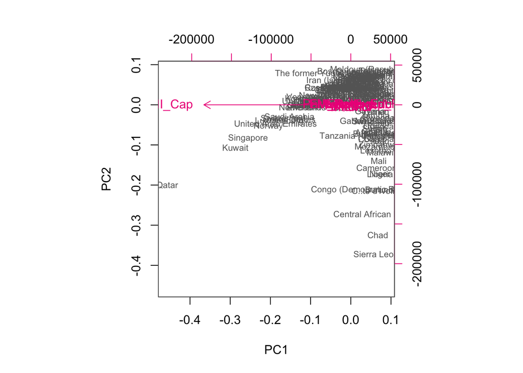

Figure 1. A PCA biplot showing world countries on a two dimensional scale. Unscaled data, which makes the plot heavily distorted by the GNI variance.

```r
# perform principal component analysis (with the SVD method)
pca_human1 <- prcomp(human)

# draw a biplot of the principal component representation and the original variables
biplot(pca_human1, choices = 1:2, cex = c(0.7, 1), col = c("grey40", "deeppink2"))
```

As the plot implies, the PCA doesn’t exactly work with unscaled data as it is heavily distorted by the GNI variable. PCA assumes variables with larger variance are ore important than variables with saller variance (Nieminen & Kämäräinen, 2017). Hence, let’s make a better analysis by scaling all the variables.

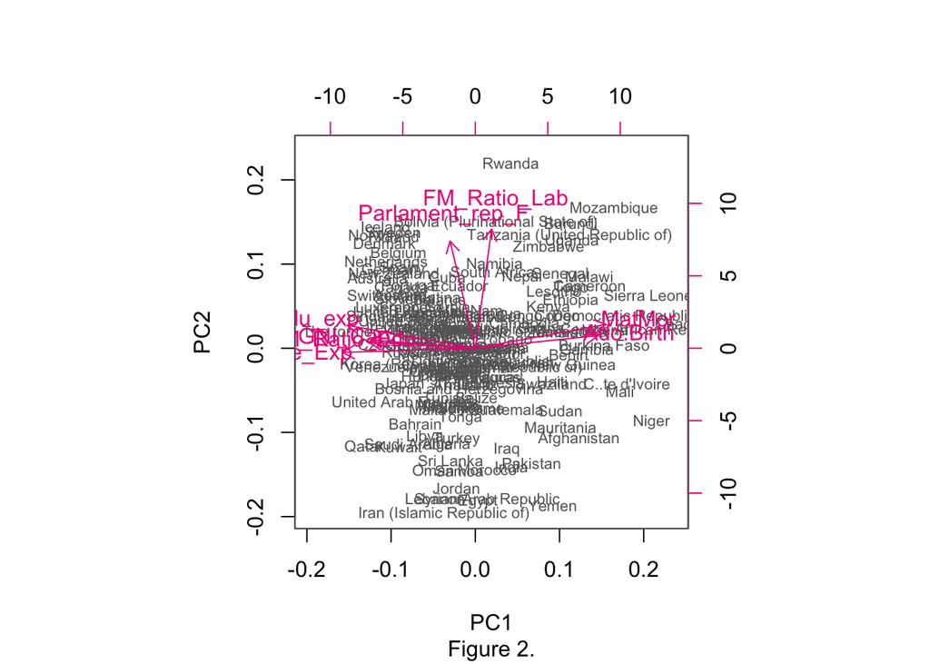

Figure 2. A PCA biplot showing world countries on a two dimensional scale. PC1 = Standard of living (negative), PC2 = Gender equality in politics and work.

```r
# standardize the variables
human_std <- scale(human)

# perform principal component analysis (with the SVD method)
pca_human2 <- prcomp(human_std)

# draw a biplot of the principal component representation and the original variables
biplot(pca_human2, choices = 1:2, cex = c(0.7, 1), col = c("grey40", "deeppink2"), main = " ", sub = "Figure 2.")
```

```r
#fig.cap = "caption"
```

PC1 here could be indicated to negatively represent general standard of living measured by mortality/health rates and national income, randing from developed countries on the left side of the plot to developing countries on the ride side. PC2, which is situated orthogonally to PC1, indicates the status of women in the society measured by the ratio of women in the parliament and in the working life.

## Let’s have some tea next!

Then to something completely different. We will next explore the tea-drinking habits of people using a tea datase from factominer. Let’s first explore the data a bit. It has 300 observations and 36 different variables.

```r
library(FactoMineR)
data("tea")
str(tea)
```

```
## 'data.frame':    300 obs. of  36 variables:
##  $ breakfast       : Factor w/ 2 levels "breakfast","Not.breakfast": 1 1 2 2 1 2 1 2 1 1 ...
##  $ tea.time        : Factor w/ 2 levels "Not.tea time",..: 1 1 2 1 1 1 2 2 2 1 ...
##  $ evening         : Factor w/ 2 levels "evening","Not.evening": 2 2 1 2 1 2 2 1 2 1 ...
##  $ lunch           : Factor w/ 2 levels "lunch","Not.lunch": 2 2 2 2 2 2 2 2 2 2 ...
##  $ dinner          : Factor w/ 2 levels "dinner","Not.dinner": 2 2 1 1 2 1 2 2 2 2 ...
##  $ always          : Factor w/ 2 levels "always","Not.always": 2 2 2 2 1 2 2 2 2 2 ...
##  $ home            : Factor w/ 2 levels "home","Not.home": 1 1 1 1 1 1 1 1 1 1 ...
##  $ work            : Factor w/ 2 levels "Not.work","work": 1 1 2 1 1 1 1 1 1 1 ...
##  $ tearoom         : Factor w/ 2 levels "Not.tearoom",..: 1 1 1 1 1 1 1 1 1 2 ...
##  $ friends         : Factor w/ 2 levels "friends","Not.friends": 2 2 1 2 2 2 1 2 2 2 ...
##  $ resto           : Factor w/ 2 levels "Not.resto","resto": 1 1 2 1 1 1 1 1 1 1 ...
##  $ pub             : Factor w/ 2 levels "Not.pub","pub": 1 1 1 1 1 1 1 1 1 1 ...
##  $ Tea             : Factor w/ 3 levels "black","Earl Grey",..: 1 1 2 2 2 2 2 1 2 1 ...
##  $ How             : Factor w/ 4 levels "alone","lemon",..: 1 3 1 1 1 1 1 3 3 1 ...
```

[output cut: 22 more lines]

```r
dim(tea)
```

```
## [1] 300  36
```

```r
#summary(tea)
```

We notice that there is one integer variable in the data (age). Since we will soon use Correspondence Analysis, which accepts only category variables, we will transform the integer varibale age to a factor variable with 10-year levels.

```r
tea$age2 <- cut(tea$age, breaks = c(15, 25, 35, 45, 55, 65, 75, 85))
tea_ <- select(tea, -age)
```

After this the royal we here notices that there already exists a factorized variable age_Q in the data. Oh well.

```r
tea_ <- select(tea_, -age2) #overlyhonestmethods
```

In any case, the full data set is rather large for visualization, so let’s pick a few interesting varibales to investigate.

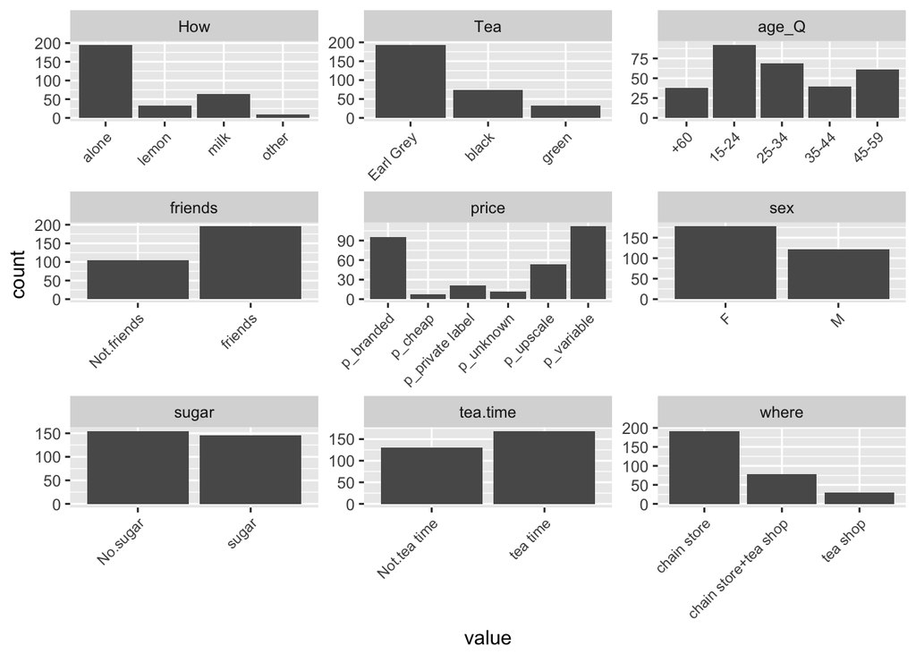

```r
# column names to keep in the dataset
keep_columns <- c("Tea", "How", "age_Q", "where", "friends", "sugar", "price", "tea.time", "sex")

# select the 'keep_columns' to create a new dataset tea_time
tea_time <- select(tea_, one_of(keep_columns))

gather(tea_time) %>% ggplot(aes(value)) + facet_wrap("key", scales = "free") + geom_bar() + theme(axis.text.x = element_text(angle = 45, hjust = 1, size = 8))
```

Next we will run a Multiple Correspondence Analysis on the tea data, first with the the full dataset and then with some selected columns.

```r
# multiple correspondence analysis
mca <- MCA(tea_, graph = FALSE)

# summary of the model
summary(mca)
```

```
##
## Call:
## MCA(X = tea_, graph = FALSE)
##
##
## Eigenvalues
##                        Dim.1   Dim.2   Dim.3   Dim.4   Dim.5   Dim.6
## Variance               0.090   0.082   0.070   0.063   0.056   0.053
## % of var.              5.838   5.292   4.551   4.057   3.616   3.465
## Cumulative % of var.   5.838  11.130  15.681  19.738  23.354  26.819
##                        Dim.7   Dim.8   Dim.9  Dim.10  Dim.11  Dim.12
## Variance               0.050   0.048   0.047   0.044   0.041   0.040
## % of var.              3.272   3.090   3.053   2.834   2.643   2.623
## Cumulative % of var.  30.091  33.181  36.234  39.068  41.711  44.334
##                       Dim.13  Dim.14  Dim.15  Dim.16  Dim.17  Dim.18
## Variance               0.039   0.037   0.036   0.035   0.034   0.032
## % of var.              2.531   2.388   2.302   2.275   2.172   2.085
## Cumulative % of var.  46.865  49.252  51.554  53.829  56.000  58.086
##                       Dim.19  Dim.20  Dim.21  Dim.22  Dim.23  Dim.24
## Variance               0.031   0.031   0.030   0.028   0.027   0.026
## % of var.              2.013   2.011   1.915   1.847   1.740   1.686
## Cumulative % of var.  60.099  62.110  64.025  65.872  67.611  69.297
##                       Dim.25  Dim.26  Dim.27  Dim.28  Dim.29  Dim.30
## Variance               0.025   0.025   0.024   0.024   0.023   0.022
## % of var.              1.638   1.609   1.571   1.524   1.459   1.425
## Cumulative % of var.  70.935  72.544  74.115  75.639  77.099  78.523
##                       Dim.31  Dim.32  Dim.33  Dim.34  Dim.35  Dim.36
## Variance               0.021   0.020   0.020   0.019   0.019   0.018
## % of var.              1.378   1.322   1.281   1.241   1.222   1.152
## Cumulative % of var.  79.901  81.223  82.504  83.745  84.967  86.119
##                       Dim.37  Dim.38  Dim.39  Dim.40  Dim.41  Dim.42
## Variance               0.017   0.017   0.016   0.015   0.015   0.014
## % of var.              1.092   1.072   1.019   0.993   0.950   0.924
## Cumulative % of var.  87.211  88.283  89.301  90.294  91.244  92.169
##                       Dim.43  Dim.44  Dim.45  Dim.46  Dim.47  Dim.48
## Variance               0.014   0.013   0.012   0.011   0.011   0.010
## % of var.              0.891   0.833   0.792   0.729   0.716   0.666
## Cumulative % of var.  93.060  93.893  94.684  95.414  96.130  96.796
##                       Dim.49  Dim.50  Dim.51  Dim.52  Dim.53  Dim.54
## Variance               0.010   0.009   0.009   0.008   0.007   0.006
```

[output cut: 48 more lines]

```
## dinner        |  0.796  1.805  0.048  3.777 |
## Not.dinner    | -0.060  0.136  0.048 -3.777 |
##
## Categorical variables (eta2)
##                 Dim.1 Dim.2 Dim.3
## breakfast     | 0.031 0.000 0.011 |
## tea.time      | 0.240 0.000 0.003 |
## evening       | 0.040 0.087 0.062 |
## lunch         | 0.062 0.029 0.010 |
## dinner        | 0.092 0.000 0.048 |
## always        | 0.056 0.035 0.007 |
## home          | 0.016 0.002 0.030 |
## work          | 0.075 0.020 0.022 |
## tearoom       | 0.321 0.019 0.031 |
## friends       | 0.186 0.061 0.030 |
```

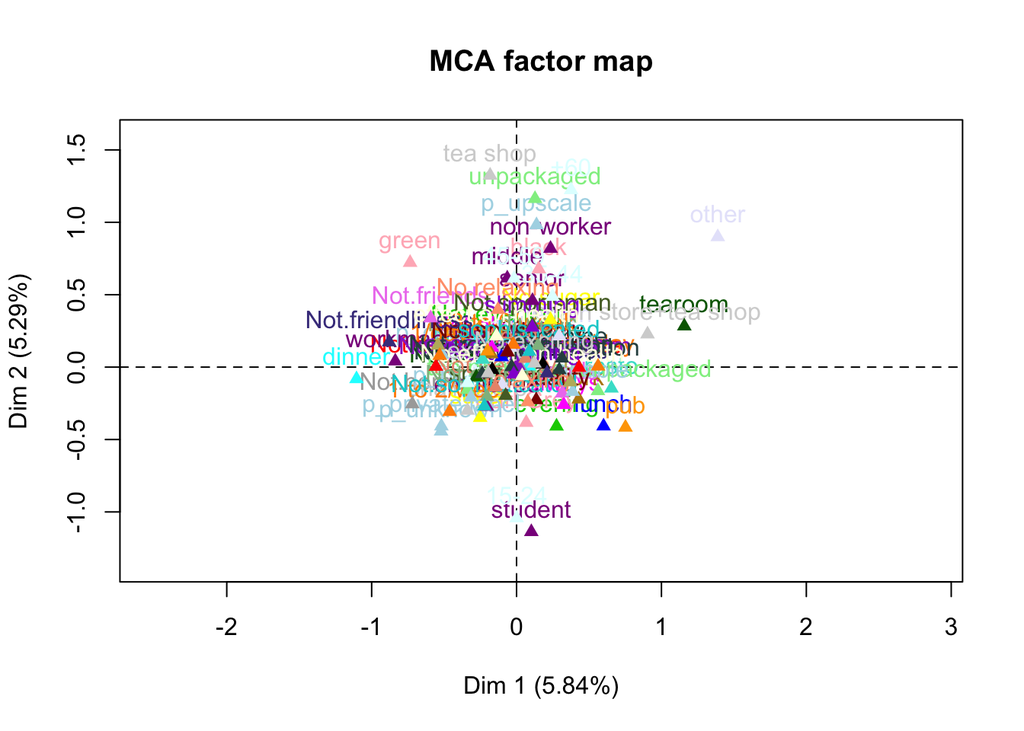

```r
# visualize MCA
plot(mca, invisible=c("ind"), habillage = "quali")
```

```r
# plot(mca, invisible=c("ind","var"))
```

The plot for the full dataset is rather difficult to interpret since all variables are gathered near the center of the plot. Let’s move on by using just the selected variables and try to investigate hos differently aged individuals use tea.

```r
tea_time2 <- select(tea_time, -price, -How)

# multiple correspondence analysis
mca_sub <- MCA(tea_time2, graph = FALSE)

# summary of the model
summary(mca_sub)
```

```
##
## Call:
## MCA(X = tea_time2, graph = FALSE)
##
##
## Eigenvalues
##                        Dim.1   Dim.2   Dim.3   Dim.4   Dim.5   Dim.6
## Variance               0.253   0.237   0.184   0.159   0.147   0.135
## % of var.             14.737  13.813  10.715   9.278   8.567   7.866
## Cumulative % of var.  14.737  28.550  39.265  48.543  57.111  64.977
##                        Dim.7   Dim.8   Dim.9  Dim.10  Dim.11  Dim.12
## Variance               0.123   0.111   0.110   0.101   0.079   0.077
## % of var.              7.173   6.468   6.405   5.897   4.610   4.471
## Cumulative % of var.  72.150  78.618  85.023  90.920  95.529 100.000
##
## Individuals (the 10 first)
##                         Dim.1    ctr   cos2    Dim.2    ctr   cos2
## 1                    |  0.500  0.329  0.110 |  0.384  0.208  0.065 |
## 2                    | -0.006  0.000  0.000 |  0.692  0.673  0.272 |
## 3                    | -0.514  0.349  0.232 |  0.049  0.003  0.002 |
## 4                    |  0.681  0.611  0.357 | -0.476  0.319  0.175 |
## 5                    |  0.441  0.257  0.128 |  0.337  0.160  0.075 |
## 6                    |  0.453  0.271  0.161 | -0.169  0.040  0.022 |
## 7                    | -0.236  0.074  0.034 |  0.049  0.003  0.001 |
## 8                    | -0.480  0.304  0.112 |  0.625  0.549  0.190 |
## 9                    | -0.293  0.113  0.040 |  0.308  0.134  0.044 |
## 10                   |  0.013  0.000  0.000 |  0.729  0.749  0.207 |
##                       Dim.3    ctr   cos2
## 1                     0.142  0.036  0.009 |
## 2                    -0.848  1.306  0.409 |
## 3                    -0.573  0.596  0.289 |
## 4                    -0.274  0.136  0.058 |
## 5                    -0.691  0.866  0.315 |
## 6                    -0.469  0.400  0.172 |
## 7                     0.222  0.089  0.030 |
## 8                    -0.202  0.074  0.020 |
## 9                     0.409  0.304  0.078 |
## 10                    0.399  0.289  0.062 |
##
## Categories (the 10 first)
```

[output cut: 17 more lines]

```
## 35-44                  0.027   2.867 |   0.686   4.882   0.072   4.654 |
## 45-59                  0.130   6.241 |  -1.046  17.315   0.279  -9.141 |
## +60                    0.144   6.557 |   0.848   7.090   0.104   5.587 |
## chain store            0.046  -3.716 |  -0.488  11.871   0.424 -11.260 |
## chain store+tea shop   0.000  -0.323 |   0.871  15.357   0.267   8.932 |
##
## Categorical variables (eta2)
##                        Dim.1 Dim.2 Dim.3
## Tea                  | 0.116 0.527 0.023 |
## age_Q                | 0.307 0.566 0.496 |
## where                | 0.216 0.141 0.424 |
## friends              | 0.116 0.129 0.144 |
## sugar                | 0.160 0.273 0.086 |
## tea.time             | 0.450 0.001 0.011 |
## sex                  | 0.404 0.020 0.102 |
```

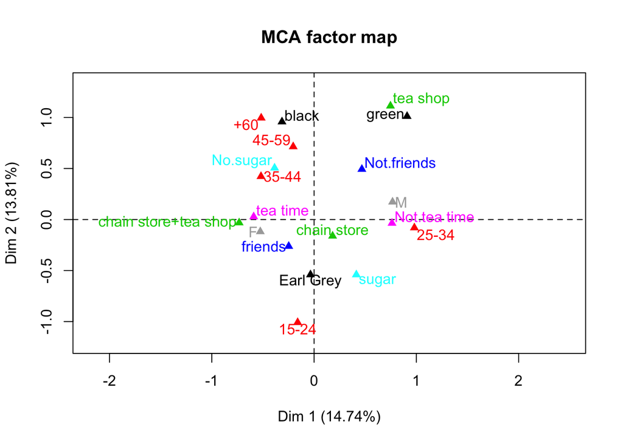

```r
# visualize MCA
plot(mca_sub, invisible=c("ind"), habillage = "quali")
```

```r
# plot(mca, invisible=c("ind","var"))
```

After several rounds of testing different variables no heureka findings emerged, but the final pot above indicates some patterns: respondents drink green tea alone and Earl Grey ith friends. Sugar and Earl Grey tend to go together. Green tea is bought from a tea shop.

Regarding the demographic variables it seems that yonger respondents don’t care about any particular tea time, whereas older generations do. Teenagers like Earl Grey with sugar; middle aged and older drink black tea without sugar. Males tend to drink tea alone, women with friends.

Over and out!